# **Predicting weight lifting quality**

Shamik Mitra

March 27, 2016

Human Activity Recognition has gained importance thanks to the vast number of affordable data collection devices, like Jawbone Up, Nike FuelBand, Fitbit and even smart phones. Using accelerometers and gyroscopes embedded within these devices, it is possible to gather a large amount of data, which can then be analyzed to identify patterns. Most of the data analyses has focused on identifying the activity. Velloso, et.al.<sup>[1]</sup> have used data to identify the quality of the activity. Six young health participants were asked to perform one set of 10 repetitions of the Unilateral Dumbbell Biceps Curl in five different fashions: exactly according to the specification (Class A), throwing the elbows to the front (Class B), lifting the dumbbell only halfway (Class C), lowering the dumbbell only halfway (Class D) and throwing the hips to the front (Class E).

This paper uses a subset of the data available through the Coursera course website<sup>[2]</sup> to build a model to predict the Class, thereby predicting the quality of the activity, by using the data from sensors. The analysis tries multiple methods for analysis and compares them using cross-validation techniques. It then uses the best alternative to create the final model to be used for prediction.

# Data loading and pre-processing

```r
## load the required libraries and set the seed
library(caret)
library(gplots)
set.seed(1)
## Read data
pmltraining <- read.csv("pml-training.csv", na.strings = c("NA","#DIV/0!"))
```

A quick inspection of the data shows that the data consists of measurements in sets. Every set of data is followed by a row that contains the summary information about the data. A number of the summary columns are filled in only for these summary rows. As part of preprocessing the data, the summary rows are removed and the columns of the table that are only filled in for the summary rows are deleted.

```r
## Remove summary rows
pmltraining <- pmltraining[pmltraining$new_window!="yes",]
## Count the number of non NA rows in each column. If it is 0, then add it to a list of columns to be dropped
DropCols <- list()
for(RowCounter in 1:ncol(pmltraining)) if(length(which(!is.na(pmltraining[,RowCounter])))==0) {
    DropCols <- c(DropCols,names(pmltraining)[RowCounter])
}
## Create a subset of data dropping all the columns that have no data
pmltraining <- pmltraining[,!(names(pmltraining) %in% DropCols)]
```

Looking at the variation of the data for the various *classe* variables shows that it is indeed possible to identify some patterns in the data that would lead us to identify the *classe*. There are 4 charts below. The first chart shows the distribution of the *pitch_forearm* variable for each of the *classe* values. As it can be seen, the values associated with **classe A** show a different distribution than the rest. The second figure shows the variation of the *magnet_dumbbell_x* for each of the *classe* values and it shows a different distribution of **classe A** and **C** compared to the rest. The fourth chart shows a different variation for **classe E** for the *magnet_belt_y* variable. The third chart shows a lower variation for **classe D** for the *accel_forearm_x* variation. Note that not all classes need to be identified. Identifying 4 of them will help to identify the 5<sup>th</sup> by elimination.

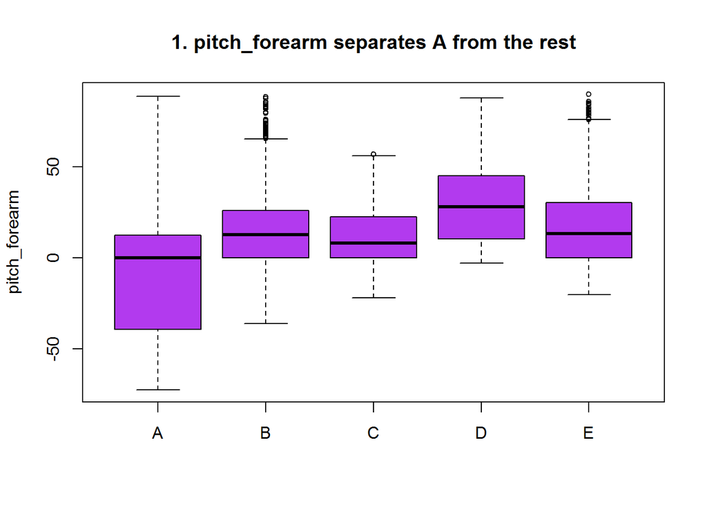

```r
plot(pmltraining$classe,pmltraining$pitch_forearm, ylab="pitch_forearm",main="1. pitch_forearm separates A from the rest", cex=0.7, col="darkorchid2", bg="red")
```

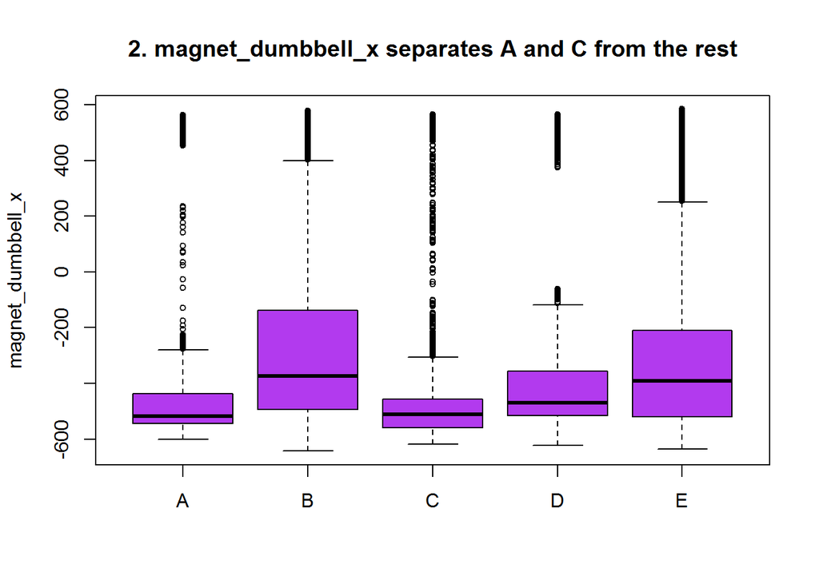

```r
plot(pmltraining$classe,pmltraining$magnet_dumbbell_x, ylab="magnet_dumbbell_x",main="2. magnet_dumbbell_x separates A and C from the rest", cex=0.7, col="darkorchid2")
```

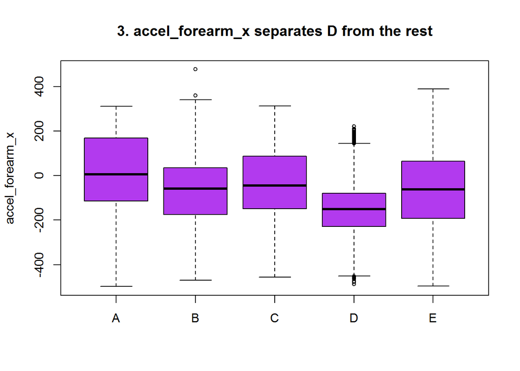

```r
plot(pmltraining$classe,pmltraining$accel_forearm_x, ylab="accel_forearm_x",main="3. accel_forearm_x separates D from the rest", cex=0.7, col="darkorchid2")
```

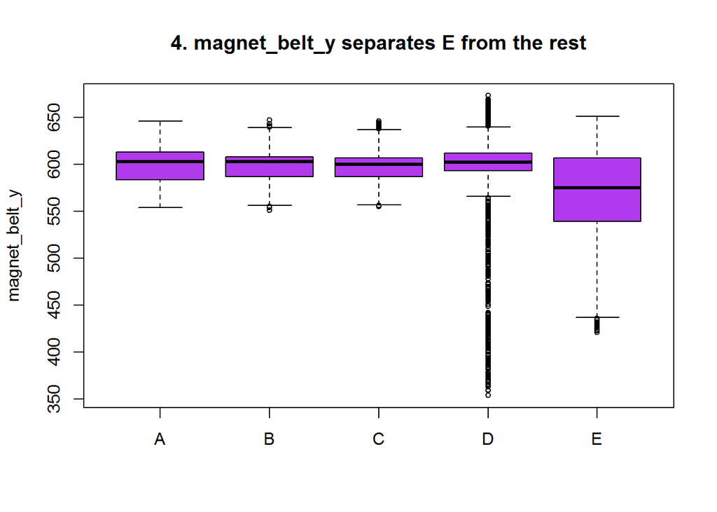

```r
plot(pmltraining$classe,pmltraining$magnet_belt_y, ylab="magnet_belt_y",main="4. magnet_belt_y separates E from the rest", cex=0.7, col="darkorchid2")
```

# Building a classification model

As can see above, just a visual inspection shows some kind of classification for each of the 5 *classe* values. To better analyze this variation, more advanced statistical methods can be used. To do this analysis, a generic function is developed that can perform any kind of training using the *caret* package’s train function. The function takes the following arguments.

- **ModelData**: The input data on which the analysis needs to be done
- **ModelType**: The type of model to be used
- **TrainingDataRatio**: The ratio of data to be used for training. If it is 1, then 100% of the data is used for training and the function returns the fitted model. If it is less than 1 then the function is run for cross validation and it returns the accuracy of the model.
- **NumOfRuns**: The number of times the model should be run. It is useful when the model is being run when the Training Data Ratio is less than 1 for cross validation.

Note that the data is a time series, where typically a K-fold cross validation would be useful. However, the data is clustered together by the *num_window* column. So the function uses a variation of the random subsampling method where instead of taking completely random samples, the function takes a random sample of the *num_window* column and then takes all the observations for that *num_window*.

```r
FitModel <- function(ModelData, ModelType, TrainingDataRatio, NumOfRuns=1, ...) {
    AccuracyNumerator <- 0
    for(RunCounter in 1:NumOfRuns) {
        uniqueNumWindow <- unique(ModelData$num_window)
        TrainingNums <- createDataPartition(y=uniqueNumWindow,p=TrainingDataRatio, list=FALSE)
        TrainingData <- ModelData[ModelData$num_window %in% TrainingNums,]
        TrainingData <- TrainingData[-c(1:7)]
        ModelFit <- train(classe~., method=ModelType, data=TrainingData, ...)
        if(TrainingDataRatio < 1) {
            TestingData <- ModelData[!ModelData$num_window %in% TrainingNums,]
            TestingData <- TestingData[-c(1:7)]
            PredictedValues <- predict(ModelFit, newdata = TestingData)
            ConfMatrix <- table(PredictedValues, TestingData$classe)
            diag(ConfMatrix) <- 0
            AccuracyNumerator <- AccuracyNumerator + 1 - (sum(ConfMatrix)/nrow(TestingData))
        }
    }
    if(TrainingDataRatio < 1){
        AccuracyNumerator / NumOfRuns
    } else {
        ModelFit
    }
}
```

The function above is used to execute the code for multiple types of methods. Each time, it performs the subsampling with 75% of the data used for training and 25% for validation, and runs it 5 times. The table below the code shows the out-of-sample accuracy (**1 - out-of-sample error rate**) of each of the model as well as the time it takes to run the model.

*Note: The Gradient Boosting (gbm) method is run only once instead of the 5 runs. This is due to computer hardware restrictions. The model gave a system memory error when run more than once,*

The times shown in the table below are for comparison purposes. They obviously depend on the hardware used. This report was generation on Microsoft Surface Pro 3, 4-core Intel i5 CPU with 64-bit Windows 10 Pro OS and 8GB RAM.

```r
## cross validate using rpart
start.time <- Sys.time()
Accuracy <- FitModel(pmltraining, "rpart", 0.75, NumOfRuns=5)
rpartAccuracy <- paste(round(Accuracy*100,0),"%",sep = "")
end.time <- Sys.time()
Duration <- (end.time - start.time)/5
rpartDuration <- paste(round(Duration,1),units(Duration))
```

```r
## cross validate using rf
start.time <- Sys.time()
rfAccuracy <- FitModel(pmltraining, "rf", 0.75, NumOfRuns=5)
rfAccuracy <- paste(round(rfAccuracy*100,0),"%",sep = "")
end.time <- Sys.time()
Duration <- (end.time - start.time)/5
rfDuration <- paste(round(Duration,1),units(Duration))
```

```r
## cross validate using treebag
start.time <- Sys.time()
treebagAccuracy <- FitModel(pmltraining, "treebag", 0.75, NumOfRuns=5)
treebagAccuracy <- paste(round(treebagAccuracy*100,0),"%",sep = "")
end.time <- Sys.time()
Duration <- (end.time - start.time)/5
treebagDuration <- paste(round(Duration,1),units(Duration))
```

```r
## cross validate using gbm
start.time <- Sys.time()
gbmAccuracy <- FitModel(pmltraining, "gbm", 0.75, NumOfRuns=1, verbose=FALSE)
gbmAccuracy <- paste(round(gbmAccuracy*100,0),"%",sep = "")
end.time <- Sys.time()
Duration <- (end.time - start.time)/1
gbmDuration <- paste(round(Duration,1),units(Duration))
```

```r
## cross validate using lda
start.time <- Sys.time()
ldaAccuracy <- FitModel(pmltraining, "lda", 0.75, NumOfRuns=5)
ldaAccuracy <- paste(round(ldaAccuracy*100,0),"%",sep = "")
end.time <- Sys.time()
Duration <- (end.time - start.time)/5
ldaDuration <- paste(round(Duration,1),units(Duration))
```

```r
## cross validate using nb
start.time <- Sys.time()
nbAccuracy <- FitModel(pmltraining, "nb", 0.75, NumOfRuns=5)
nbAccuracy <- paste(round(nbAccuracy*100,0),"%",sep = "")
end.time <- Sys.time()
Duration <- (end.time - start.time)/5
nbDuration <- paste(round(Duration,1),units(Duration))
```

**Comparison of models**

| Model | Accuracy | Duration |
| --- | --- | --- |
| Basic Tree (rpart) | 48% | 0.3 mins |
| Random Forrest (rf) | 93% | 2.9 hours |
| Bagged Tree (treebag) | 91% | 0.3 hours |
| Stochastic Gradient Boosting (gbm) | 90% | 52.9 mins |
| Linear Discriminate Analysis (lda) | 65% | 0.2 mins |
| Naive Bayes (nb) | 69% | 1.1 hours |

# Final model

As shown above the Random Forest method has the highest accuracy, even though it takes the longest time. To build the final model we run the same function, but this time with 100% of the training data. As the last step of the analysis, this model is then used to predict the values of the test set of the data. The output is not shown here, but instead saved in a file.

```r
##Fit the final model with the complete training data
FinalModel <- FitModel(pmltraining, "rf", 1, NumOfRuns=1)

##Read the validation data and drop the columns not required
pmlvalidation <- read.csv("pml-testing.csv", na.strings = c("NA","#DIV/0!"))
pmlvalidation <- pmlvalidation[ , !(names(pmlvalidation) %in% DropCols)]

##Predict the values of the classe variable using the fitted model and store it in a file
pmlvalidation$classe <- predict(FinalModel, newdata = pmlvalidation)
write.csv(pmlvalidation,"model-output.csv")
```

The table below shows the normalized confusion matrix of the model. As we expected because of the high accuracy above, it does a good job of correctly classifying most of the data. Please refer to the Appendix for the detailed analysis for each of the other models.

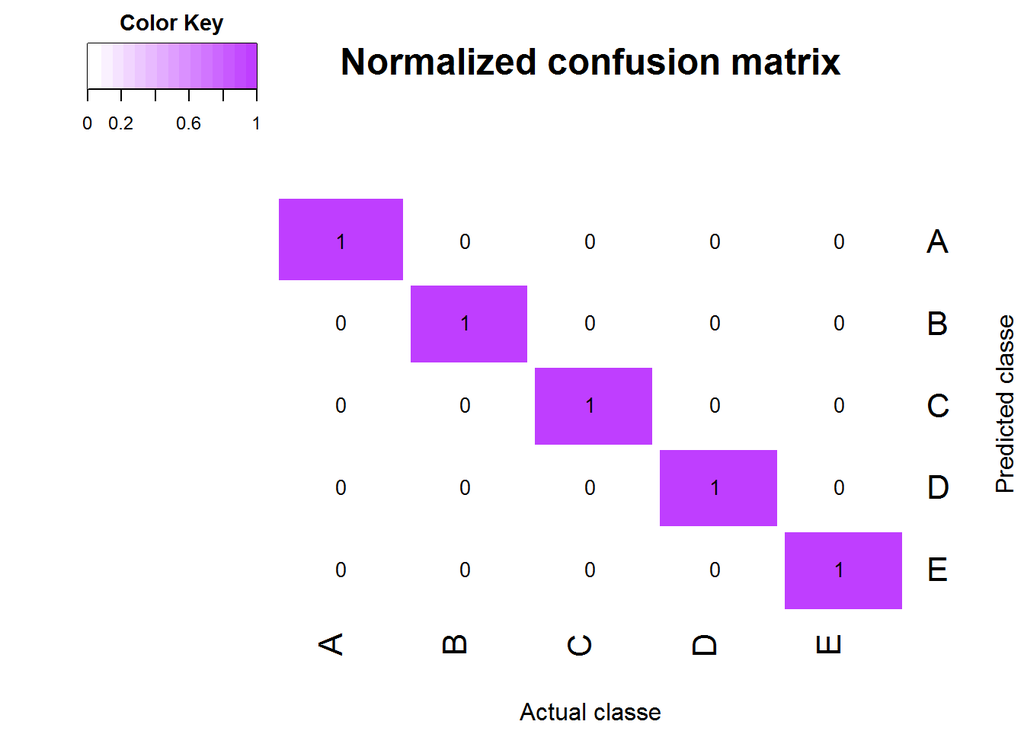

```r
##Predict using the pmltraining data
PredictedValues <- predict(FinalModel, newdata = pmltraining)
ConfMatrix <- table(PredictedValues, pmltraining$classe)

##Normalize the confusion matrix
for (i in 1:5) {
    colsum <- sum(ConfMatrix[,i])
    for (j in 1:5) ConfMatrix[j,i] <- round(ConfMatrix[j,i]/colsum,2)
}

##Generate a heat map for the confusion matrix
heatmap.2(ConfMatrix, Rowv = FALSE, Colv = FALSE, col=colorRampPalette(c("white","darkorchid1")),
          cellnote = ConfMatrix, notecol = "black", trace="none", density.info="none", key=TRUE,
          key.xlab = "", main="Normalized confusion matrix", colsep = c(1,2,3,4), rowsep = c(1,2,3,4),
          sepcolor = "white", xlab = "Actual classe", ylab = "Predicted classe")
```

**References:**

<sup>[1]</sup> [Velloso, E.; Bulling, A.; Gellersen, H.; Ugulino, W.; Fuks, H. Qualitative Activity Recognition of Weight Lifting Exercises. Proceedings of 4th International Conference in Cooperation with SIGCHI (Augmented Human ’13). Stuttgart, Germany: ACM SIGCHI, 2013.](http://groupware.les.inf.puc-rio.br/work.jsf?p1=11201)

<sup>[2]</sup> [Coursera Practical Machine Learning Assignment page.](https://www.coursera.org/learn/practical-machine-learning/peer/R43St/prediction-assignment-writeup)

# Appendix: Results of other models

Here are the results of all the other models. The code behind each of the models has been suprressed. It essentially uses the same function above to run each model type.

## Basic Tree

```
## CART
##
## 19060 samples
##    52 predictor
##     5 classes: 'A', 'B', 'C', 'D', 'E'
##
## No pre-processing
## Resampling: Bootstrapped (25 reps)
## Summary of sample sizes: 19060, 19060, 19060, 19060, 19060, 19060, ...
## Resampling results across tuning parameters:
##
##   cp          Accuracy   Kappa       Accuracy SD  Kappa SD
##   0.02755751  0.5581835  0.43401165  0.02053253   0.03383735
##   0.04135095  0.4677098  0.29933563  0.06036704   0.10274774
##   0.11475771  0.3301722  0.06930229  0.04049647   0.06272681
##
## Accuracy was used to select the optimal model using  the largest value.
## The final value used for the model was cp = 0.02755751.
```

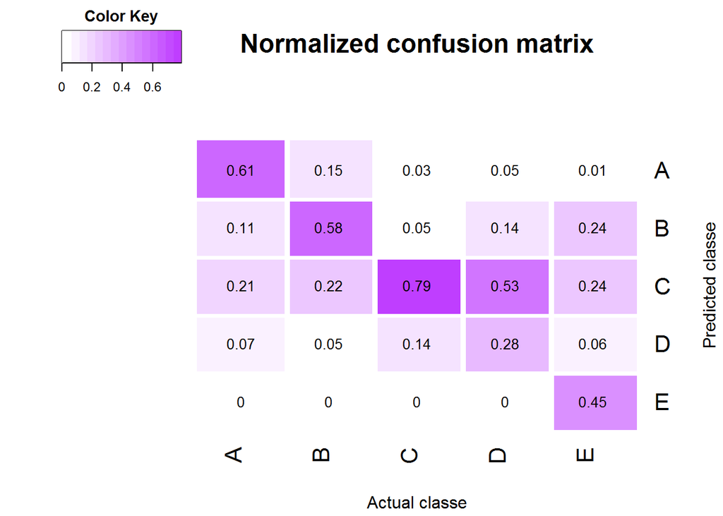

## Bagged Tree

```
## Bagged CART
##
## 19060 samples
##    52 predictor
##     5 classes: 'A', 'B', 'C', 'D', 'E'
##
## No pre-processing
## Resampling: Bootstrapped (25 reps)
## Summary of sample sizes: 19060, 19060, 19060, 19060, 19060, 19060, ...
## Resampling results
##
##   Accuracy   Kappa      Accuracy SD  Kappa SD
##   0.9837222  0.9793959  0.004521512  0.005722267
##
##
```

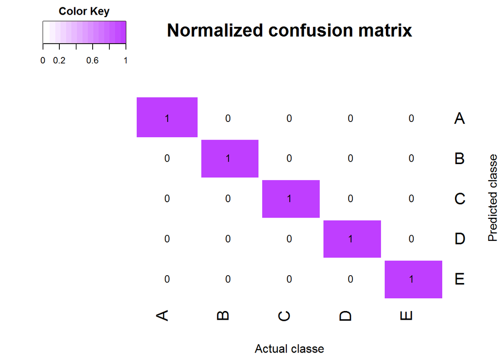

## Stochastic Gradient Boosting

```
## Stochastic Gradient Boosting
##
## 19060 samples
##    52 predictor
##     5 classes: 'A', 'B', 'C', 'D', 'E'
##
## No pre-processing
## Resampling: Bootstrapped (25 reps)
## Summary of sample sizes: 19060, 19060, 19060, 19060, 19060, 19060, ...
## Resampling results across tuning parameters:
##
##   interaction.depth  n.trees  Accuracy   Kappa      Accuracy SD
##   1                   50      0.7502336  0.6832488  0.006721971
##   1                  100      0.8192844  0.7711700  0.005673787
##   1                  150      0.8532727  0.8142376  0.004949647
##   2                   50      0.8543402  0.8153721  0.005658917
##   2                  100      0.9050826  0.8798302  0.004332000
##   2                  150      0.9290856  0.9102264  0.003513327
##   3                   50      0.8966466  0.8691001  0.005633506
##   3                  100      0.9397669  0.9237513  0.003389673
##   3                  150      0.9585407  0.9475272  0.002915549
##   Kappa SD
##   0.008455172
##   0.007158828
##   0.006246781
##   0.007151655
##   0.005460460
##   0.004443408
##   0.007136815
##   0.004292261
##   0.003683945
##
## Tuning parameter 'shrinkage' was held constant at a value of 0.1
##
## Tuning parameter 'n.minobsinnode' was held constant at a value of 10
## Accuracy was used to select the optimal model using  the largest value.
## The final values used for the model were n.trees = 150,
##  interaction.depth = 3, shrinkage = 0.1 and n.minobsinnode = 10.
```

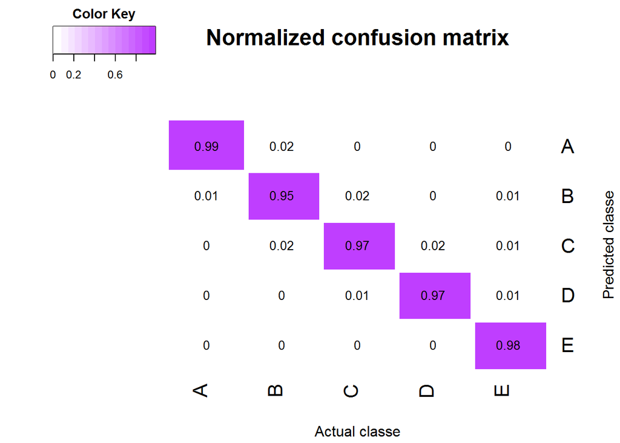

## Linear Discriminate Analysis

```
## Linear Discriminant Analysis
##
## 19060 samples
##    52 predictor
##     5 classes: 'A', 'B', 'C', 'D', 'E'
##
## No pre-processing
## Resampling: Bootstrapped (25 reps)
## Summary of sample sizes: 19060, 19060, 19060, 19060, 19060, 19060, ...
## Resampling results
##
##   Accuracy   Kappa    Accuracy SD  Kappa SD
##   0.7008474  0.62144  0.004211574  0.005304917
##
##
```

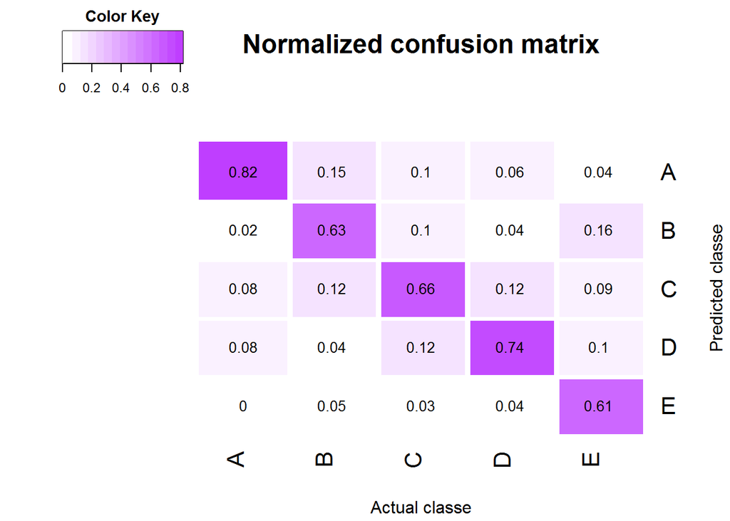

## Naive Bayes

```
## Naive Bayes
##
## 19060 samples
##    52 predictor
##     5 classes: 'A', 'B', 'C', 'D', 'E'
##
## No pre-processing
## Resampling: Bootstrapped (25 reps)
## Summary of sample sizes: 19060, 19060, 19060, 19060, 19060, 19060, ...
## Resampling results across tuning parameters:
##
##   usekernel  Accuracy   Kappa      Accuracy SD  Kappa SD
##   FALSE      0.5139793  0.3975281  0.031521696  0.03339736
##    TRUE      0.7452293  0.6751687  0.007794928  0.01196049
##
## Tuning parameter 'fL' was held constant at a value of 0
## Accuracy was used to select the optimal model using  the largest value.
## The final values used for the model were fL = 0 and usekernel = TRUE.
```

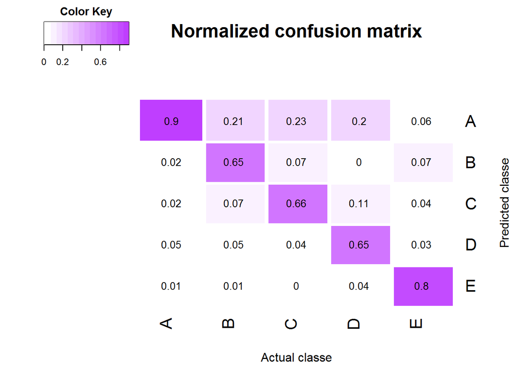